# 计算机视觉实践 第4次课，作者：邓擎琼

# 本次课我们将学到：

全局阈值分割方法和透视变换，实现选择题答题卡的自动判分：

[figure not shown]

## **1. 图像分割**

图像分割是指将图像分成若干具有相似性质的区域的过程，

主要有基于阈值、基于区域、基于边缘、基于聚类、基于图论和基于深度学习的图像分割方法等。

分割的原则就是使划分后的子图在内部保持相似度最大，而子图之间的相似度保持最小。

图像分割分为语义分割和实例分割。

- 语义分割：将图像中的每个像素分配给其对应的语义类别
- 实例分割：将图像中的每个物体分割成独立的实例

[figure not shown]

上节课的案例：

[figure not shown]

### **1.1 阈值分割**

包括固定阈值分割、Otsu法（最大类间方差法、大律法）、三角法自动阈值分割和自适应阈值分割（下次课介绍）等。

参考文档：https://docs.opencv.org/4.x/d7/d4d/tutorial_py_thresholding.html

#### **1.1.1 固定阈值分割**

基本思想：假设图像中有明显的目标和背景，则其灰度直方图呈双峰分布，

当灰度级直方图具有双峰特性时，选取两峰之间的谷对应的灰度级作为阈值。

固定阈值分割采用全局阈值。

```python
#先导入相关的库，定义显示图像函数
import cv2
import numpy as np
import matplotlib.pyplot as plt

def cv_show(name,img): #窗口名字，图像
    cv2.imshow(name,img)
    cv2.waitKey(0)
    cv2.destroyAllWindows()

def plt_show(name, img, sub=111): #标题，图像，子窗口id
    plt.subplot(sub)
    plt.imshow(cv2.cvtColor(img, cv2.COLOR_BGR2RGB))
    plt.title(name)
    plt.axis("off")
    if (sub-100)//10==(sub-100)%10:
        plt.show()
```

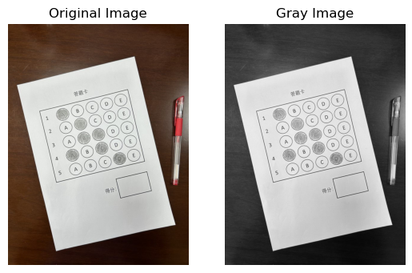

```python
'''读入图像文件，转成灰度图'''
img = cv2.imread("Images/1.jpg")
imgGray = cv2.cvtColor(img, cv2.COLOR_BGR2GRAY)

plt_show('Original Image', img, 121)
plt_show("Gray Image", imgGray, 122)
```

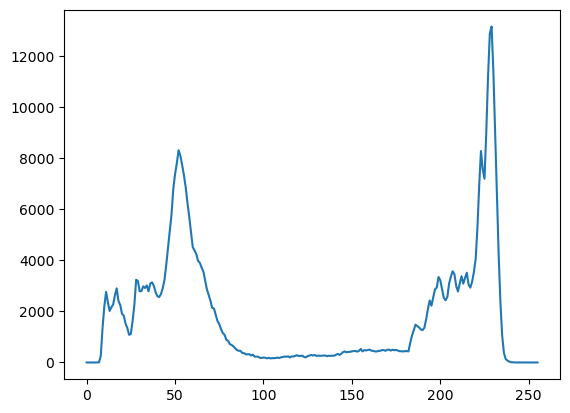

```python
imgBlur = cv2.GaussianBlur(imgGray, (3, 3), 1)
hist = cv2.calcHist([imgBlur],[0],None,[256],[0,255])

#绘制曲线图
plt.plot(hist)
plt.show()
```

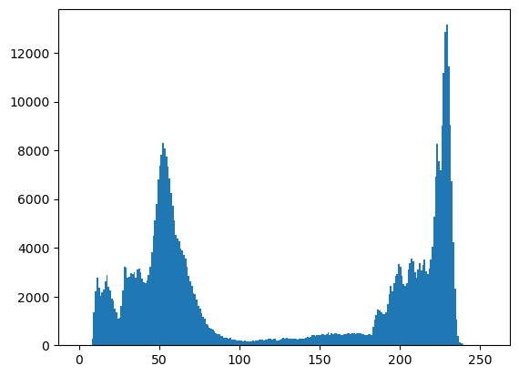

```python
plt.hist(imgBlur.ravel(),256,[0,256]) #matplotlib自带hist计算
plt.show()
```

#### 固定阈值分割API: ret, dst = cv2.threshold(src, thresh, maxval, type)

- src： 输入图（可以是多通道图像，但一般是单通道图像）
- thresh： 阈值
- maxval： 当像素值超过了阈值（或者小于阈值，根据type来决定），所赋予的值
- type：二值化操作的类型，包含以下5种类型： cv2.THRESH_BINARY； cv2.THRESH_BINARY_INV； cv2.THRESH_TRUNC； cv2.THRESH_TOZERO；cv2.THRESH_TOZERO_INV

返回值：

- ret：阈值
- dst： 输出图

type各种取值的含义：

[figure not shown]

```
180.0
```

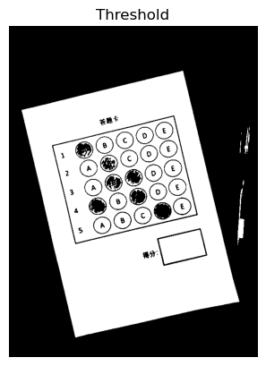

```python
ret, thresh = cv2.threshold(imgBlur, 180, 255, cv2.THRESH_BINARY)

print(ret)
plt_show('Threshold', thresh)
```

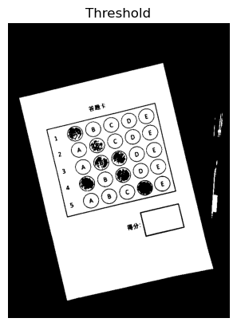

```python
#使用inRange也能得到同样的效果
thresh = cv2.inRange(imgBlur, 180, 255)

plt_show('Threshold', thresh)
```

```python
'''通过滑动条调整阈值'''
def OnTrackbar(pos):
    ret, thresh = cv2.threshold(imgBlur, pos, 255, cv2.THRESH_BINARY)
    cv2.imshow('Threshold', thresh)

cv2.namedWindow('Threshold', 0)
cv2.resizeWindow('Threshold', (img.shape[1],img.shape[0]))

cv2.createTrackbar('Thresh', 'Threshold', 0, 255, OnTrackbar)

cv2.waitKey(0)
cv2.destroyAllWindows()
```

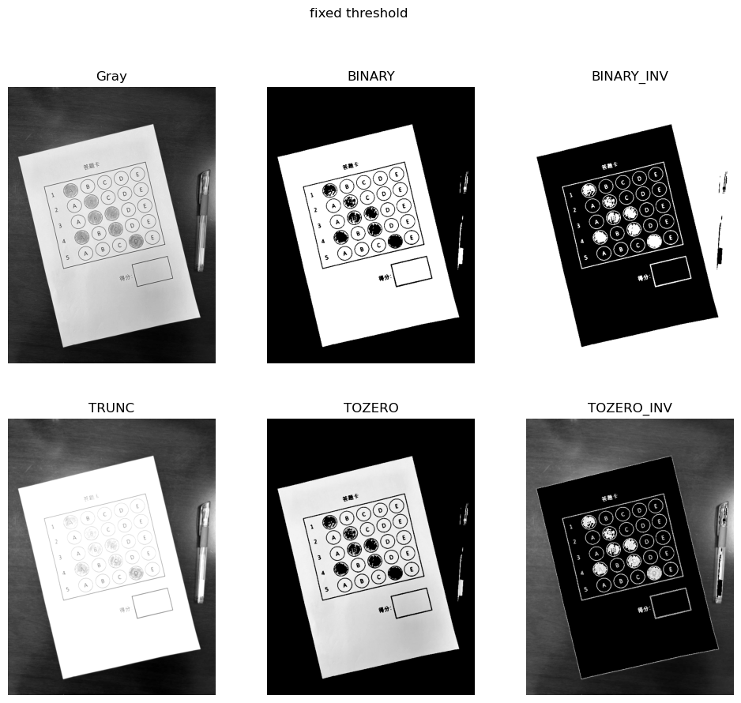

```python
'''5种不同type值对应的分割结果'''
ret, thresh1 = cv2.threshold(imgBlur, 180, 255, cv2.THRESH_BINARY)
ret, thresh2 = cv2.threshold(imgBlur, 180, 255, cv2.THRESH_BINARY_INV)
ret, thresh3 = cv2.threshold(imgBlur, 180, 255,cv2.THRESH_TRUNC)
ret, thresh4 = cv2.threshold(imgBlur, 180, 255, cv2.THRESH_TOZERO)
ret, thresh5 = cv2.threshold(imgBlur, 180, 255, cv2.THRESH_TOZERO_INV)

titles=['Gray','BINARY', 'BINARY_INV','TRUNC','TOZERO','TOZERO_INV']
images = [imgGray, thresh1, thresh2, thresh3, thresh4, thresh5]
plt.figure(figsize=(12,10))
for i in range(6):
    plt.subplot(2,3, i+1)
    plt.imshow(images[i],cmap='gray')
    plt.title(titles[i])
    plt.axis("off")

plt.suptitle('fixed threshold')
plt.show()
```

#### **1.1.2 Otsu法（最大类间方差法、大律法）**

一种基于全局阈值的自适应方法。

图像分为前景和背景。当取最佳阈值时，两部分之间的差别应该是最大的，衡量差别的标准为最大类间方差。

Otsu法迭代求解使得类间方差最大的阈值，然后以此阈值进行分割。

结合cv2.threshold()使用，参数thresh为初始阈值。

```
130.0
```

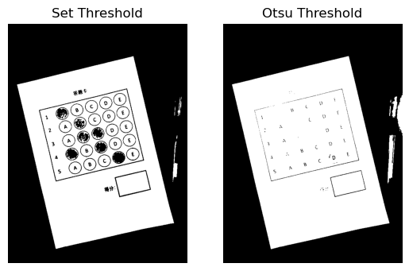

```python
#手动给定阈值
ret1, thresh1 = cv2.threshold(imgBlur, 180, 255, cv2.THRESH_BINARY)
plt_show('Set Threshold', thresh1, 121)

#Otsu方法自动求解阈值
ret2, thresh2 = cv2.threshold(imgBlur, 0, 255, cv2.THRESH_BINARY + cv2.THRESH_OTSU)
print(ret2)
plt_show('Otsu Threshold', thresh2, 122)
```

#### **1.1.3 三角法**

一种基于全局阈值的自适应方法。

适合直方图是单峰时的分割。

通过三角形求得最大直线距离，根据最大直线距离对应的直方图灰度等级即为分割阈值。

用法与Ostu法类似，只需要把cv2.THRESH_OTSU替换成cv2.THRESH_TRIANGLE。

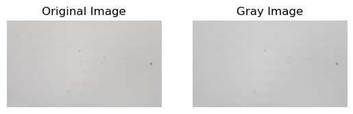

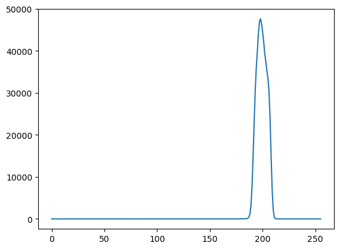

```python
imgTest = cv2.imread("Images/Cloth1.png")
imgTestGray = cv2.cvtColor(imgTest, cv2.COLOR_BGR2GRAY)
plt_show('Original Image', imgTest, 121)
plt_show("Gray Image", imgTestGray, 122)

#计算直方图
imgTestBlur = cv2.GaussianBlur(imgTestGray, (3, 3), 1)
hist = cv2.calcHist([imgTestBlur],[0],None,[256],[0,255])
plt.plot(hist)
plt.show()
```

```
199.0
```

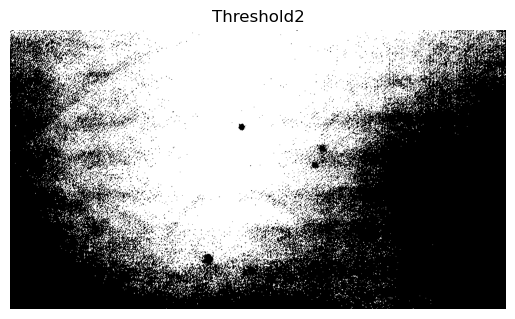

```python
'''大津法'''
ret2, thresh2 = cv2.threshold(imgTestBlur, 0, 255, cv2.THRESH_BINARY + cv2.THRESH_OTSU)
print(ret2)
plt_show('Threshold2', thresh2)
```

```
186.0
```

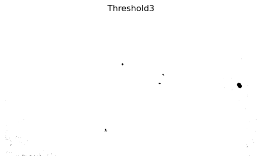

```python
'''三角法'''
ret3, thresh3 = cv2.threshold(imgTestBlur, 0, 255, cv2.THRESH_BINARY + cv2.THRESH_TRIANGLE)
print(ret3)
plt_show('Threshold3', thresh3)
```

#### 三角法原理图：

[figure not shown]

```
13
```

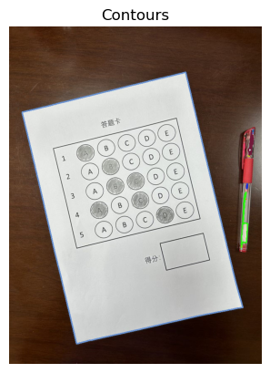

```python
'''对阈值分割后的图像求轮廓'''
contours, hier = cv2.findContours(thresh1, cv2.RETR_EXTERNAL, cv2.CHAIN_APPROX_SIMPLE)
print(len(contours))

imgContours = img.copy()
for i in range(len(contours)):
    cv2.drawContours(imgContours, contours, i, (np.random.randint(0,255), np.random.randint(0,255), np.random.randint(0,255)), 2)
plt_show('Contours',imgContours)
```

```
轮廓数量： 13
```

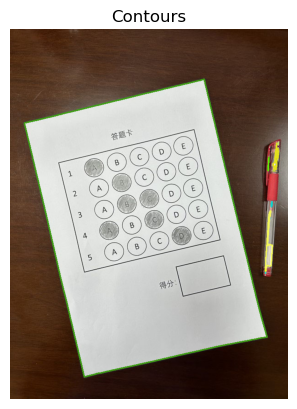

```python
'''获得并显示轮廓封装成函数'''
def findShowContours(imgCont, imgShow):
    contours, hier = cv2.findContours(imgCont, cv2.RETR_EXTERNAL, cv2.CHAIN_APPROX_SIMPLE)
    print('轮廓数量：', len(contours))

    imgContours = imgShow.copy()
    for i in range(len(contours)):
        cv2.drawContours(imgContours, contours, i, (np.random.randint(0,255), np.random.randint(0,255), np.random.randint(0,255)), 2)
    plt_show('Contours',imgContours)
    return contours

contours = findShowContours(thresh1, img)
```

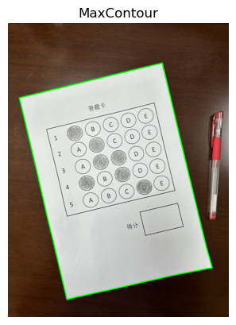

```python
#面积最大的轮廓
cnt = contours[0]
maxArea = cv2.contourArea(cnt)
maxCntId = 0
for i, cnt in enumerate(contours[1:], 1):
    area = cv2.contourArea(cnt)
    if area>maxArea:
        maxArea = area
        maxCntId = i

contour = contours[maxCntId]
imgContours = img.copy()
cv2.drawContours(imgContours, [contour], 0, (0, 255, 0), 2)
plt_show('MaxContour',imgContours)
```

## **2. 透视变换**

[figure not shown]

透视变换是从一个视角变换到另一个视角。

仿射变换处理二维场景中的平移、旋转和缩放等问题。

仿射变换需要3对点，透视变换需要4对点。

仿射变换保持平行线不变，而透视变换不保证这一点‌。

同仿射变换类似，对应的API：M = cv2.getPerspectiveTransform(pos1, pos2)

- pos1：透视变换前的4个点对应位置
- pos2：透视变换后的4个点对应位置
- 返回值M：透视变换矩阵

cv2.warpPerspective(src,M, dsize) -> dst

- src：原始图像
- M：透视变换矩阵
- dsize：表示变换后的图像大小
- 返回结果图像dst

参考文档：https://docs.opencv.org/4.x/da/d6e/tutorial_py_geometric_transformations.html

```python
print(contour)
print(len(contour))
```

```
[[[421 109]]

 [[420 110]]

 [[417 110]]

 ...

 [[423 111]]

 [[422 110]]

 [[422 109]]]
901
```

```python
# 获取近似的轮廓
arc = cv2.arcLength(contour, True)
approx = cv2.approxPolyDP(contour, 0.02 * arc, True)
print(approx, approx.shape)
```

```
[[[422 109]]

 [[ 31 204]]

 [[161 758]]

 [[559 671]]] (4, 1, 2)
```

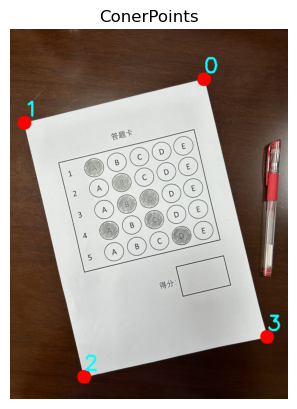

```python
# 4个顶点
approx = approx.reshape((4,2))
imgConerPoints = img.copy()
for i, pnt in enumerate(approx):
    cv2.circle(imgConerPoints, (pnt[0], pnt[1]), 15, (0, 0, 255), -1)
    cv2.putText(imgConerPoints, f'{i}', (pnt[0], pnt[1]-15), cv2.FONT_HERSHEY_SIMPLEX, 1.5, (255,255,0), 3)
plt_show('ConerPoints',imgConerPoints)
```

[figure not shown]

```
[[ 31. 204.]
 [422. 109.]
 [559. 671.]
 [161. 758.]]
```

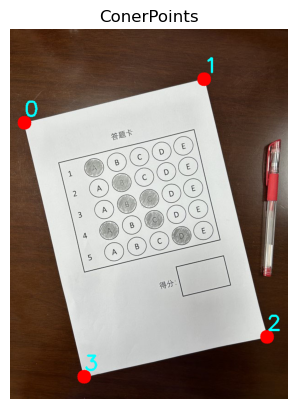

```python
def orderPoints(pts):
    '''对4点进行排序，下标0、1、2、3分别是左上、右上、右下、左下'''
    rect = np.zeros((4, 2), dtype="float32")
    # 计算左上和右下
    s = pts.sum(axis=1) #每个点的x和y相加，左上是和最小的，右下是和最大的。
    rect[0] = pts[np.argmin(s)]
    rect[2] = pts[np.argmax(s)]
    # 计算右上和左下
    diff = np.diff(pts, axis=1)#每个点的y-x，右上最小，左下最大。
    rect[1] = pts[np.argmin(diff)]
    rect[3] = pts[np.argmax(diff)]
    return rect

#排好序之后的结果
pntsOrded = orderPoints(approx)
print(pntsOrded)
imgConerPoints = img.copy()
for i, pnt in enumerate(pntsOrded):
    cv2.circle(imgConerPoints, (int(pnt[0]), int(pnt[1])), 15, (0, 0, 255), -1)
    cv2.putText(imgConerPoints, f'{i}', (int(pnt[0]), int(pnt[1])-15), cv2.FONT_HERSHEY_SIMPLEX, 1.5, (255,255,0), 3)
plt_show('ConerPoints',imgConerPoints)
```

```
变换矩阵： [[ 1.00217438e+00 -2.35167272e-01  1.69067179e+01]
 [ 2.43232354e-01  1.00109316e+00 -2.11763208e+02]
 [ 4.48185549e-05  1.15745350e-05  1.00000000e+00]]
```

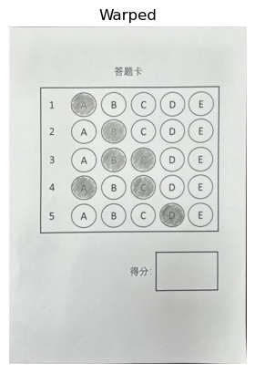

```
变换矩阵： [[ 1.00217438e+00 -2.35167272e-01  1.69067179e+01]
 [ 2.43232354e-01  1.00109316e+00 -2.11763208e+02]
 [ 4.48185549e-05  1.15745350e-05  1.00000000e+00]]
```

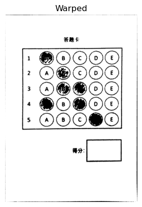

```python
def perspectiveTransform(pntsOrded, img):
    tl, tr, br, bl = pntsOrded
    # 计算输入的w和h值
    widthA = np.sqrt(((br[0] - bl[0]) ** 2) + ((br[1] - bl[1]) ** 2))
    widthB = np.sqrt(((tr[0] - tl[0]) ** 2) + ((tr[1] - tl[1]) ** 2))
    maxWidth = max(int(widthA), int(widthB))

    heightA = np.sqrt(((tr[0] - br[0]) ** 2) + ((tr[1] - br[1]) ** 2))
    heightB = np.sqrt(((tl[0] - bl[0]) ** 2) + ((tl[1] - bl[1]) ** 2))
    maxHeight = max(int(heightA), int(heightB))

    # 变换后对应坐标位置
    dst = np.array([
        [0, 0],
        [maxWidth - 1, 0],
        [maxWidth - 1, maxHeight - 1],
        [0, maxHeight - 1]], dtype="float32")


    # 计算变换矩阵
    M = cv2.getPerspectiveTransform(pntsOrded, dst)
    print("变换矩阵：", M)
    warped = cv2.warpPerspective(img, M, (maxWidth, maxHeight))
    plt_show('Warped',warped)
    return warped

paper = perspectiveTransform(pntsOrded, img)
paperThresh = perspectiveTransform(pntsOrded, thresh1)
```

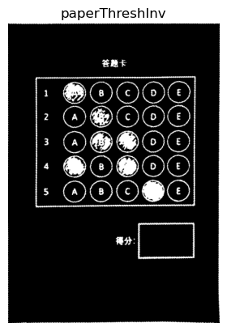

```python
'''涂黑的地方是选项，因此需反向'''
paperThreshInv = cv2.bitwise_not(paperThresh)
#也可以用下面这行代码实现反
#retInv, paperThreshInv = cv2.threshold(paperThresh,50,255,cv2.THRESH_BINARY_INV)
plt_show('paperThreshInv', paperThreshInv)
```

```
轮廓数量： 178
```

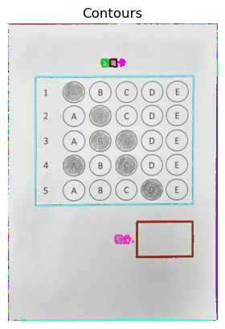

```python
contours = findShowContours(paperThreshInv, paper)
```

```python
#获得形状是长方形且面积足够大的轮廓
rectCon = []
for cnt in contours:
    area = cv2.contourArea(cnt)
    if area > 80:
        arc = cv2.arcLength(cnt, True)
        approx = cv2.approxPolyDP(cnt, 0.02 * arc, True)
        if len(approx)==4:
            rectCon.append(approx)

rectCon.sort(key=cv2.contourArea,reverse=True) #根据面积排序

print(len(rectCon))
print(rectCon)
```

```
2
[array([[[360, 101]],

       [[ 54, 103]],

       [[ 52, 354]],

       [[359, 351]]], dtype=int32), array([[[250, 385]],

       [[250, 454]],

       [[358, 452]],

       [[357, 384]]], dtype=int32)]
```

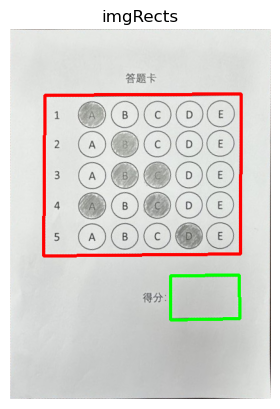

```python
imgRects = paper.copy()
rect1 = np.array(rectCon[0]).reshape(-1,1,2)  #最大的轮廓
cv2.polylines(imgRects, [rect1], True, (0,0,255), 3)

rect2 = np.array(rectCon[1]).reshape(-1,1,2)   #第二大的轮廓
cv2.polylines(imgRects, [rect2], True, (0,255,0), 3)
plt_show('imgRects',imgRects)
```

```
变换矩阵： [[ 9.96737857e-01  7.94213432e-03 -5.46418841e+01]
 [ 6.53557810e-03  9.99943449e-01 -1.03347096e+02]
 [-1.28176189e-05  1.28741638e-05  1.00000000e+00]]
```

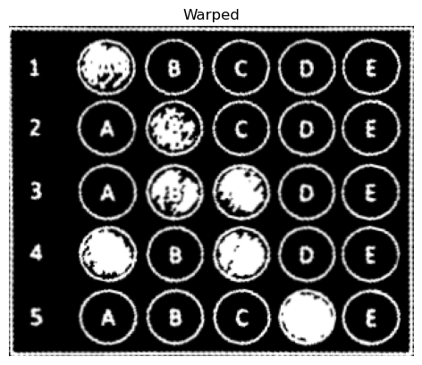

```python
rect1Orded = orderPoints(rect1.reshape((-1,2))) #对最大轮廓的四个顶点排序
choices = perspectiveTransform(rect1Orded, paperThreshInv)[3:-3,3:-3]  #做透视变换并去掉边缘
ret, choices = cv2.threshold(choices, 100, 255, cv2.THRESH_BINARY)
```

```
轮廓数量： 137
```

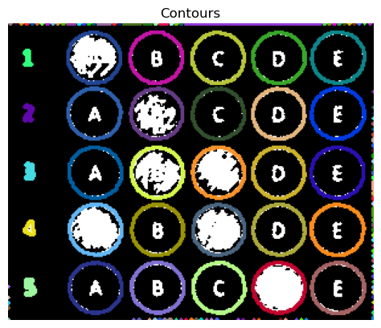

```python
rect1Color = choices.copy()
rect1Color = cv2.cvtColor(rect1Color, cv2.COLOR_GRAY2BGR)

contours = findShowContours(choices, rect1Color)
```